# R Notebook

```r
library(glmnet)
library(RCurl)
```

# 7.9.

- Data http://www.statsci.org/data/general/brunhild.html,
- About Data: dataset measures the concentration of a sulfate in the blood of a baboon named Brunhilda as a function of time.

#### (a) Prepare a plot showing (a) the data points and (b) the regression line in log-log coordinates.

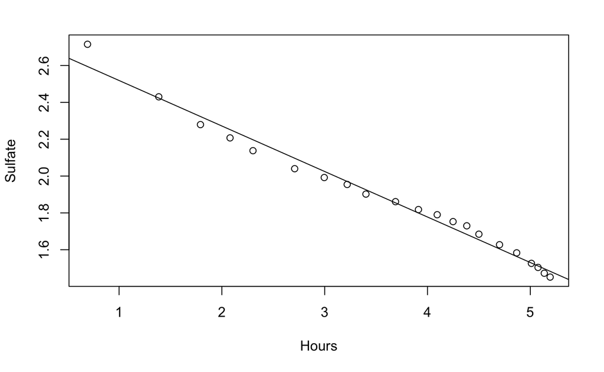

```r
plot(log(data) )
abline(lm(formula = Sulfate~Hours, data = log(data)))
```

```r
#model <- lm(formula = Sulfate~Hours, data = log(data))
```

#### (b) Prepare a plot showing (a) the data points and (b) the regression curve in the original coordinates.

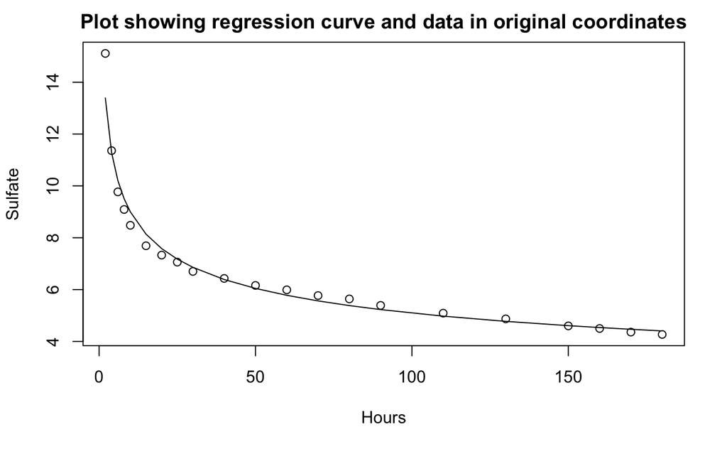

```r
model <- lm(formula = Sulfate~Hours, data = log(data))
fitted <- exp(as.numeric(model$fitted.values))
plot(data, main ="Plot showing regression curve and data in original coordinates")
lines(data$Hours, fitted)
```

#### (c) Plot the residual against the fitted values in log-log and in original coordinates.

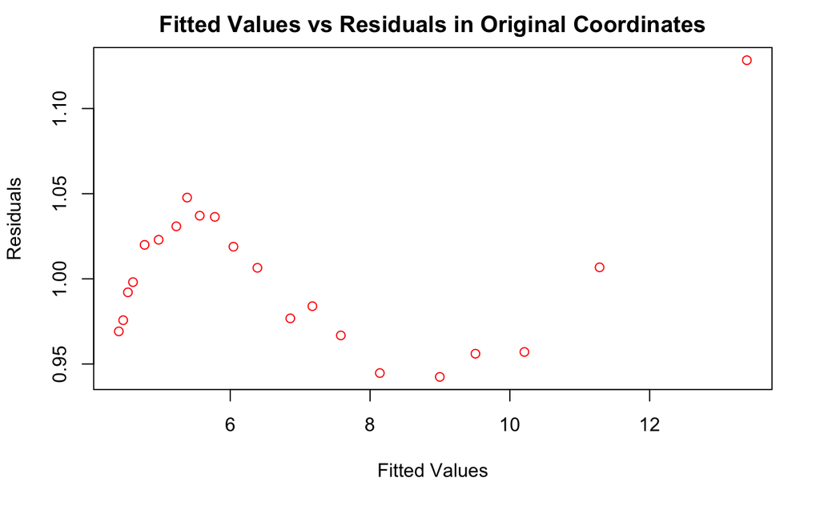

```r
##Original coordinates
plot(x= fitted, y= exp(model$residuals), main = 'Fitted Values vs Residuals in Original Coordinates', xlab ='Fitted Values', ylab='Residuals', col='red')
```

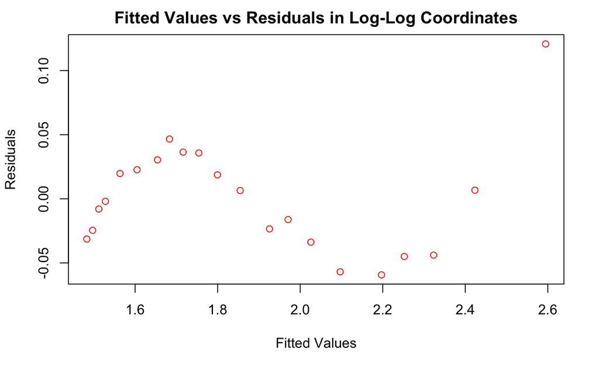

```r
##Log log coordinates
plot(x= model$fitted.values, y= model$residuals, main = 'Fitted Values vs Residuals in Log-Log Coordinates', xlab ='Fitted Values', ylab='Residuals', col='red')
```

#### (d) Use your plots to explain whether your regression is good or bad and why.

# 7.10

- Data: http://www.statsci.org/data/oz/physical.html
- About data: body measurement dataset

#### (a) Plot the residual against the fitted values for your regression.

```r
url <- getURL("http://www.statsci.org/data/oz/physical.txt")
dat <- read.table(text = url, header = TRUE)
model1 <- lm(Mass ~., data = dat)
plot(fitted(model1), resid(model1))
abline(h = 0)
```

[output not shown]

#### (b) Now regress the cube root of mass against these diameters. Plot theresidual against the fitted values in both these cube root coordinates and in the original coordinates.

```r
# (b)Now regress the cube root of mass against these diameters.
model2 <- lm(Mass^(1/3) ~., data = dat)

# Plot the residual against the fitted values (cube root coordinates)
plot(fitted(model2), resid(model2))
abline(h = 0)
# Plot the residual against the fitted values (original coordinates)
plot(fitted(model2)^3, resid(model2))
abline(h = 0)
```

[output not shown]

#### (c) Use your plots to explain which regression is better.

# 7.11

Data Source: https://archive.ics.uci.edu/ml/machine-learning-databases/abalone/

```r
df <- read.csv("abalone.data",col.names =c("Sex","Length","Diameter","Height","WholeWeight","ShuckedWeight","VisceraWeight","ShellWeight","Rings"), stringsAsFactors = FALSE)

#based on data documetation, we can obtian age of Abalone in years by adding 1.5 to the ring column.
df$Age <- df$Rings+1.5
```

#### A.Build a linear regression predicting the age from the measurements, ignoring gender. Plot the residual against the fitted values.

```r
# we will be removing Sex, age and Rings from the features (Rings is like a age)


model.fit <- lm(formula = Age~Length+Length+Height+WholeWeight+ShuckedWeight+VisceraWeight+ShellWeight, data = df)

plot(x = model.fit$fitted.values, y =model.fit$residuals,type = "p" ,main = "Residuals vs Fitted Value",xlab = "Fitted Value", ylab = "Residuals")
```

[output not shown]

#### (b)Build a linear regression predicting the age from the measurements, including gender. There are three levels for gender; I’m not sure whetherthis has to do with abalone biology or difficulty in determining gender.You can represent gender numerically by choosing 1 for one level, 0 foranother, and -1 for the third. Plot the residual against the fitted values.

```r
df$Sex[df$Sex == "F"] =-1
df$Sex[df$Sex == "I"] =0
df$Sex[df$Sex == "M"] =1

model.fit <- lm(formula = Age~Length+Length+Height+WholeWeight+ShuckedWeight+VisceraWeight+ShellWeight+Sex, data = df)

plot(x = model.fit$fitted.values, y =model.fit$residuals,type = "p" ,main = "Residuals vs Fitted Value",xlab = "Fitted Value", ylab = "Residuals")
```

[output not shown]

#### (c) Now build a linear regression predicting the log of age from the measurements, ignoring gender. Plot the residual against the fitted values.

```r
dfLog <- df
dfLog$Age <- log(df$Age)

model.fit <- lm(formula = Age~Length+Length+Height+WholeWeight+ShuckedWeight+VisceraWeight+ShellWeight, data = dfLog)

plot(x = model.fit$fitted.values, y =model.fit$residuals,type = "p" ,main = "Residuals vs Fitted Value",xlab = "Fitted Value", ylab = "Residuals")
```

[output not shown]

#### (d) Now build a linear regression predicting the log age from the measurements, including gender, represented as above. Plot the residual against the fitted values.

```r
model.fit <- lm(formula = Age~Length+Length+Height+WholeWeight+ShuckedWeight+VisceraWeight+ShellWeight+Sex, data = dfLog)

plot(x = model.fit$fitted.values, y =model.fit$residuals,type = "p" ,main = "Residuals vs Fitted Value",xlab = "Fitted Value", ylab = "Residuals")
```

[output not shown]

#### (e) It turns out that determining the age of an abalone is possible, but difficult(you section the shell, and count rings). Use your plots to explain whichregression you would use to replace this procedure, and why.

#### (f) Can you improve these regressions by using a regularizer? Use glmnet toobtain plots of the cross-validated prediction error.

```r
features <- subset(names(df),!(names(df) %in% c("Sex","Rings","Age")))
outcome <- c("Age")
#7.11a
model.fit <- cv.glmnet(x= data.matrix(df[,features]), y=data.matrix(df[,outcome]),alpha = 0)
plot(model.fit, sub = "7.11a using regularizer")


#7.11b
#including sex
features <- subset(names(df),!(names(df) %in% c("Rings","Age")))
model.fit <- cv.glmnet(x= data.matrix(df[,features]), y=data.matrix(df[,outcome]),alpha = 0)
plot(model.fit, sub = "7.11b using regularizer")


#7.11c
# now log the age and ignore gender
features <- subset(names(df),!(names(df) %in% c("Sex","Rings","Age")))
model.fit <- cv.glmnet(x= data.matrix(dfLog[,features]), y=data.matrix(dfLog[,outcome]),alpha = 0)
plot(model.fit, sub = "7.11c using regularizer")


#7.11d
#now log the age and include gender
features <- subset(names(df),!(names(df) %in% c("Rings","Age")))
model.fit <- cv.glmnet(x= data.matrix(dfLog[,features]), y=data.matrix(dfLog[,outcome]),alpha = 0)
plot(model.fit, sub = "7.11d using regularizer")
```

[output not shown]

- From the above analysis of using regularizer, we found that both models can be improved using regularizer